# Meat

2026-02-26

## The grim reality of the present

Approximately **9 million people** die from hunger-related causes annually.

~ 1 person dies / 4 seconds

**~ Malnutrition is the leading cause of child mortality, contributing to roughly 50% of all child deaths**

Over 3 million children die from hunger annually.

## UN Sustainable Development Goals

According to the UN, hunger is the leading cause of death in humans, but this is not purely a shortage issue.  
The Huffington Post states that the world already produces enough food for everyone, but around **one third** of it is lost/wasted.

Additionally, High-income countries account for just *16%* of the world’s population and *33%* of its meat intake.” This begs the question- if we improved how we produced and distributed food (specifically meat), could we eliminate one of the leading causes of death in our species?

In this presentation we will examine meat consumption and production patterns under the lens of the **2nd and 12th** United Nations Sustainable Development Goals **(Zero Hunger and Responsible Production & Consumption)** to see how they might be altered.

## Introduction to Sample Population

**Haiti, Yemen**, and **Afghanistan** are three of the seven countries of greatest concern for hunger risk according to *Action Against Hunger*. These countries will serve as our `famine high-risk` group.

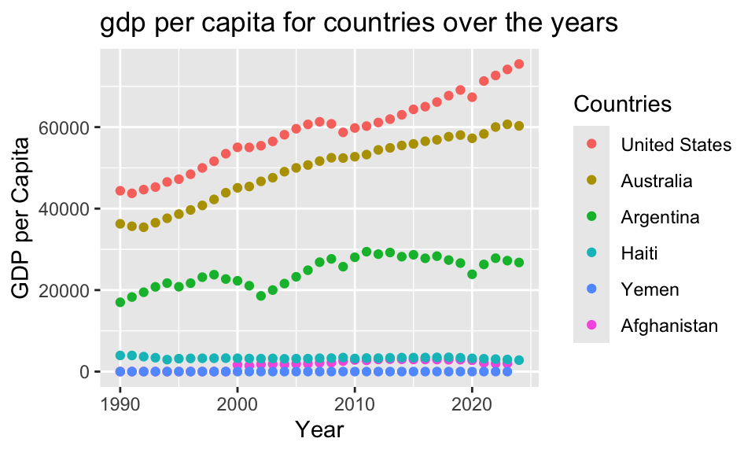

This group will contrast the `carnivore` group, which is made up of the **United States, Argentina**, and **Australia** - some of the biggest meat-consuming countries in the world (per capita).

## Consumption Patterns

Lots of Beef and Poultry!

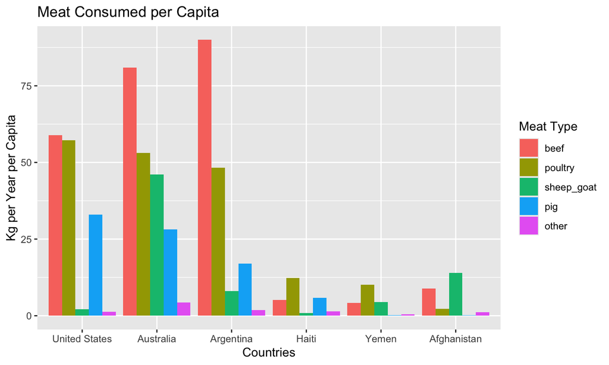

## Meat Efficiency - Responsible Production & Consumption

Feed efficiency, a critical measure in livestock production, determines how effectively animals convert feed into desired outputs like milk, eggs, or meat.

Production Efficiency also correlates with the **environmental impact** these productions have. According to a 2014 study, diets must feature less red meat, which consumes 11 times more water and results in five times more climate-warming emissions than chicken or pork.

## Chicken vs Beef

- **Broiler Chickens:** Broiler chickens have an exceptional Feed Efficiency Ratio (FER), often around 1.5 to 2.0.
  - This means for every 1.5 to 2 pounds of feed, the chicken produces 1 pound of meat.
- **Beef Steers:** Beef steers have a feed efficiency ratio of approximately 6 to 8.
  - This lower efficiency is due to their longer growth periods and higher maintenance energy requirements compared to poultry and pigs.

## With these insights, the goal seems to be to shift consumption away from beef and towards poultry.

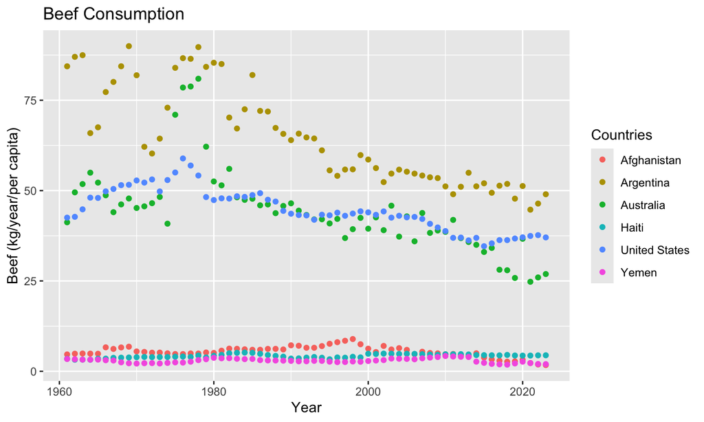

## Which is what we are already seeing!

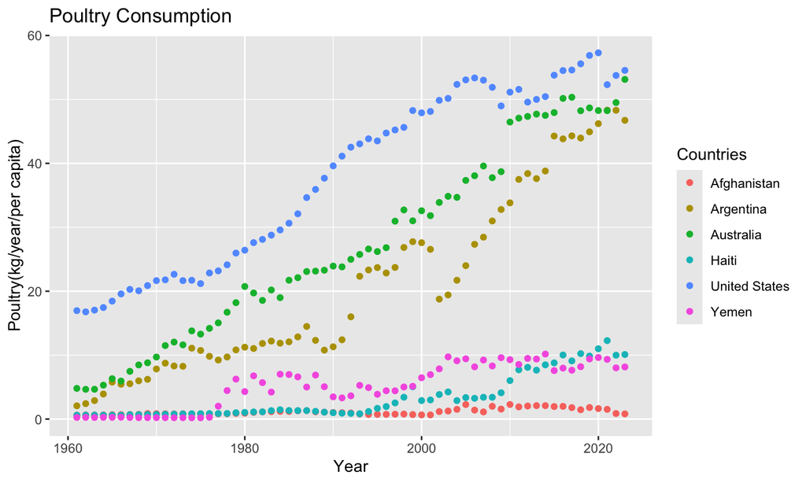

## Production trends shows some promise !

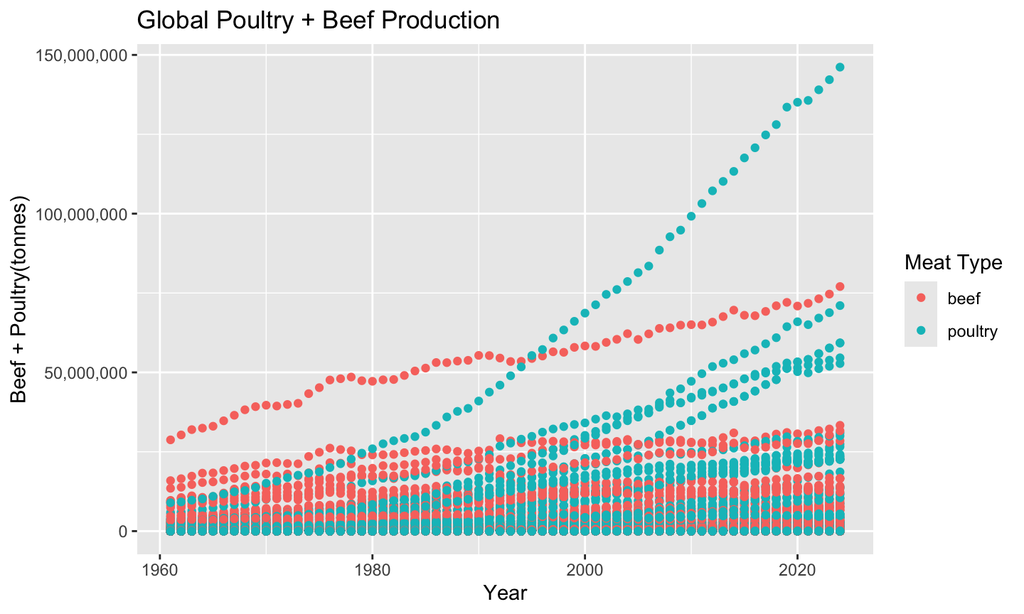

## Is it really doable?

- “I don’t think it’s all that ambitious to eliminate hunger,” said Jomo Sundaram, assistant director-general of the U.N.’s Food and Agriculture Organisation (FAO). That is because **incomes are rising** in much of the world, **transport to move food is improving**, and **new technologies** are keeping yields of many key crops on an upward trend, he said.
- Despite a rapidly rising world population, *there are 216 million fewer hungry people on earth today than in 1990*.
- The Shift to Chicken is beneficial in many sectors, making it a desirable solution.
  - Production Efficiency
  - Environmental concerns
  - Land cover usage

## Waste not Want not

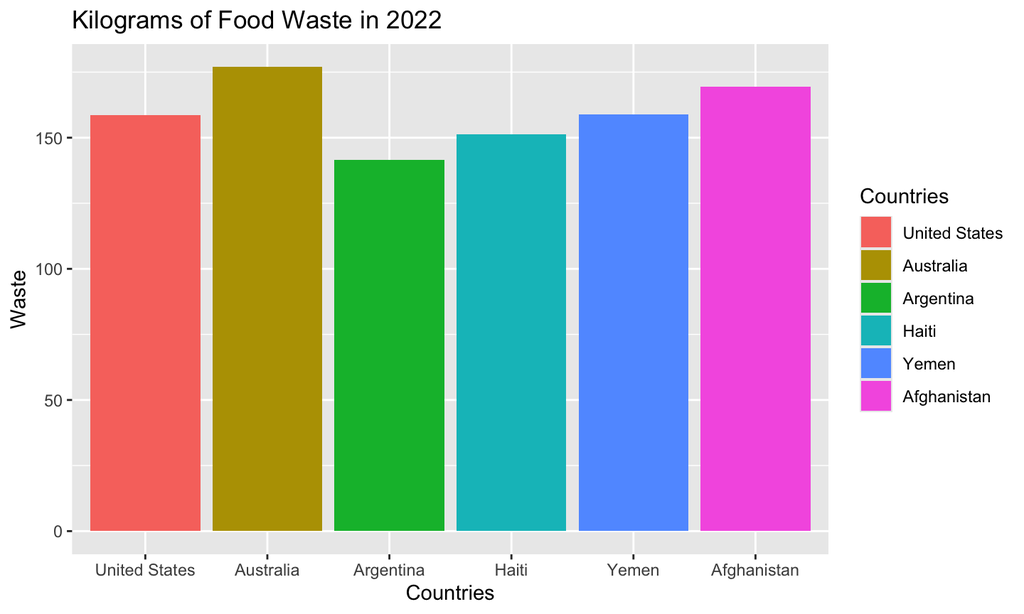

## Conclusions

- One of Humanities biggest inequalities **kills millions** each year, but it can be thwarted!
- Once we find what works best (Chicken production) we have a direction and can **implement**
  - This must happen both at the production level AND at the individual level
- The other side of the coin is **mitigating the leakage** where we lose 1/3 of our food
  - This is also a battle fought on many fronts

## Sources

- Per Capita meat consumption by type
- [meat consumption and gdp](https://ourworldindata.org/grapher/meat-consumption-vs-gdp-per-capita.csv?v=1&csvType=full&useColumnShortNames=true)
- [Meat production](https://ourworldindata.org/grapher/global-meat-production-by-livestock-type)
- [Food Waste](https://ourworldindata.org/grapher/food-waste-per-capita?overlay=download-data)
- [SDG 2](https://globalgoals.org/goals/2-zero-hunger/)
- [SDG 12](https://sdgs.un.org/goals/goal12)
- [Huffington Post](https://www.huffpost.com/entry/cutting-back-on-meat-consumption-could-help-end-hunger-by-2030-experts_n_55f3424ee4b077ca094f27a5)
- Feed Efficiency
- [Vox Chicken forecast](https://www.vox.com/future-perfect/2023/8/4/23818952/chicken-meat-forecast-predictions-beef-pork-oecd-fao)
- [Biggest meat consumers](https://www.weforum.org/stories/2018/08/these-countries-eat-the-most-meat-03bdf469-f40a-41e3-ade7-fe4ddb2a709a/)
- High hunger concern
- Meat production Efficiency